# Unit 5 - Causal Diagrams

James Flynn

September 16, 2026

## Recap

- So far we’ve worked on coding basics and data viz
- This week we are thinking about how to use these tools for **causal inference**
- We want to find ways to isolate *just the variation* that represents the effect of X on Y

## Causal inference requires modeling

- We will now think more about *how* we can identify causality in data
- Part of that will necessarily require us to have a model
  - Doesn’t need to be a big structural model
  - Doesn’t necessarily even need to be written down

## Models

- We *have to have a model* to get at causality
- A model is our way of *understanding the world*. It’s our idea of what we think the data-generating process is
- Models can be informal or formal
  - *Structural* papers typically have rigorous formal models
  - *Reduced-form* papers often have a *conceptual framework* section instead
- Even if your paper does not have a model, you need to have one in mind before you start running regressions
- All models are oversimplifications. Tradeoff between *tractability* and *usefulness*

## Models

- Once we *do* have a model, though, that model will tell us *exactly* how we can find a causal effect
- (if it’s possible; sometimes the model says that to identify we must do something impossible)
- If we have a source of identified variation in how `X` was assigned, we may be able to use that variation to get a good estimate of the treatment effect

## Example

- Let’s work through a basic example where we know the data generating process

```r
# Is your company in tech? Let's say 30% of firms are
df <- tibble(tech = sample(c(0,1),500,replace=T,prob=c(.7,.3))) %>%
  #Tech firms on average spend $3mil more defending IP lawsuits
  mutate(IP.spend = 3*tech+runif(500,min=0,max=4)) %>%
  #Tech firms also have higher profits. But IP lawsuits lower profits
  mutate(log.profit = 2*tech - .3*IP.spend + rnorm(500,mean=2))
# Now let's check for how profit and IP.spend are correlated!
cor(df$log.profit,df$IP.spend)
```

```
## [1] 0.1472215
```

- Uh-oh! Truth is negative relationship, but data says positive!!

## Example

- We want to know the causal effect of IP lawsuits on profits
- Now we can ask: *what do we know* about this situation?
- How do we suspect the data was generated? (ignoring for a moment that we know already)
  - We know that being a tech company leads you to have to spend more money on IP lawsuits
  - We know that tech companies generally have high profits
  - We know that IP lawsuits lower your profits

## Example

- Part of what we get when we calculate `cor(df$log.profit,df$IP.spend)` is the influence of being a tech company
- If we remove the influence being a tech company has on both IP spending and profits, what’s left over should be the actual, negative, effect of IP lawsuits
- What if we had a more formal model that could tell us what to do in *lots* of situations

## Causal Diagrams

- Enter the causal diagram!
- A causal diagram is a way of writing down your *model* that lets you figure out what you need to do to find your causal effect of interest
  - Also know as Directed Acyclic Graphs, or DAGs
- All you need to do to make a causal diagram is write down all the important features of the data generating process, and also write down what you think causes what.

## Example

- We know that being a tech company leads you to have to spend more money on IP lawsuits
- We know that being a tech company leads you to have higher profits
- We know that IP lawsuits lower your profits

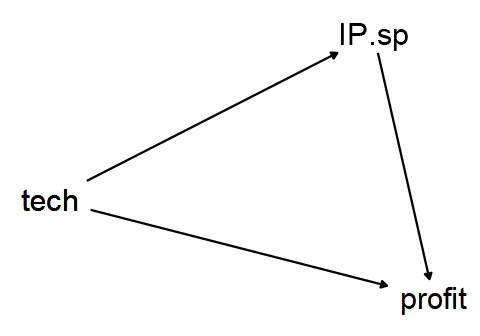

## Identification

- We have *encoded* everything we know about this particular little world in our diagram
- Not only can we see our assumptions, but we can see how they fit together
- And if we want to isolate the effect of `IP.spend` on `profit`, we can figure that out too
- We’re *identifying* just one of those arrows, the one `IP.spend -> profit`, and seeing what the effect is on that arrow!
- **If we can shut down the other arrows, there’s only one path you can walk on the diagram to get from treatment to outcome - only one kind of variation left, and it MUST be the causal effect you want**

## Controlling

- Imagine we’re looking at that relationship *within color*
- Here, being a tech company is a *confounder*

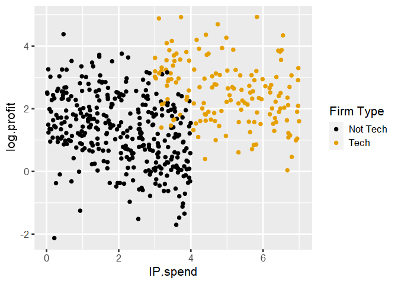

## Causal Diagrams

- The diagram that told us to control for `tech`, but we could have gotten there on our own
- It’s going to turn out that diagrams can tell us how to identify things in much more complex circumstances

## What is a mediator?

- Here is a DGP

```r
set.seed(12)
x <- rnorm(10000)
m <- rnorm(10000) + x
y <- rnorm(10000) + 2*x + 3*m
```

- What is the direct effect of x on y?
- What will we get if we regress x on y?

## Regress x on y

```r
lm1 <- lm(y~x)
summary(lm1)
```

```
##
## Call:
## lm(formula = y ~ x)
##
## Residuals:
##      Min       1Q   Median       3Q      Max
## -10.8240  -2.1565  -0.0283   2.1507  10.9876
##
## Coefficients:
##             Estimate Std. Error t value Pr(>|t|)
## (Intercept)  0.02126    0.03173    0.67    0.503
## x            4.97192    0.03168  156.95   <2e-16 ***
## ---
## Signif. codes:  0 '***' 0.001 '**' 0.01 '*' 0.05 '.' 0.1 ' ' 1
##
## Residual standard error: 3.173 on 9998 degrees of freedom
## Multiple R-squared:  0.7113, Adjusted R-squared:  0.7113
## F-statistic: 2.463e+04 on 1 and 9998 DF,  p-value: < 2.2e-16
```

## What happens when we control for a mediator?

```r
lm1 <- lm(y~x+m)
summary(lm1)
```

```
##
## Call:
## lm(formula = y ~ x + m)
##
## Residuals:
##     Min      1Q  Median      3Q     Max
## -4.4072 -0.6776 -0.0064  0.6742  4.6133
##
## Coefficients:
##             Estimate Std. Error t value Pr(>|t|)
## (Intercept) 0.001679   0.009936   0.169    0.866
## x           1.975400   0.014000 141.101   <2e-16 ***
## m           3.016492   0.009946 303.295   <2e-16 ***
## ---
## Signif. codes:  0 '***' 0.001 '**' 0.01 '*' 0.05 '.' 0.1 ' ' 1
##
## Residual standard error: 0.9936 on 9997 degrees of freedom
## Multiple R-squared:  0.9717, Adjusted R-squared:  0.9717
## F-statistic: 1.716e+05 on 2 and 9997 DF,  p-value: < 2.2e-16
```

## Mediator DAG

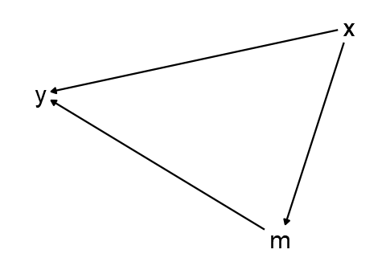

## Mediator examples

- Education → Health Knowledge → Health Outcomes
- Minimum Wage → Hours Worked → Total Earnings
- Exercise Program → Weight Loss → Blood Pressure
- Smoking Ban → Secondhand Smoke Exposure → Infant Health

## What is a collider?

```r
set.seed(12)
looks <- rnorm(10000)
talent <- rnorm(10000)
movie_star <- looks + talent > 2
df <- tibble(looks = looks, talent = talent, movie_star = movie_star)
```

## Scatter plot

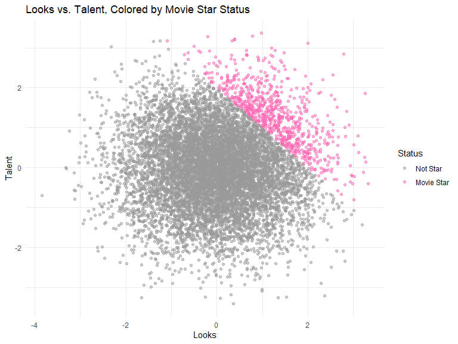

## What happens in the regression

```r
# Unconditional regression: talent on looks, full sample
summary(lm(talent ~ looks, data = df))$coefficients["looks",]
```

```
##     Estimate   Std. Error      t value     Pr(>|t|)
## -0.006619555  0.009973988 -0.663681909  0.506909223
```

```r
# Controlling for a collider in the regression
summary(lm(talent ~ looks + movie_star, data = df))$coefficients["looks",]
```

```
##      Estimate    Std. Error       t value      Pr(>|t|)
## -1.777902e-01  9.776199e-03 -1.818603e+01  9.838367e-73
```

## Collider DAG

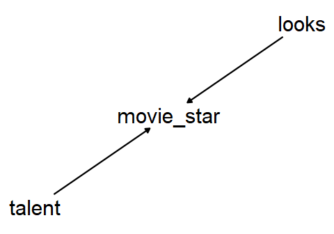

## Causal Diagrams

- Can’t we just look at the data to see what we need to control for?
- After all, that would free us from having to make all those assumptions and figure out our model
- No!!!
- Why? Because for a given set of data that we see, there are *many* different data generating processes that could have made it
- Each requiring different kinds of adjustments in order to get it right

## Causal Diagrams

- We observe that `profit` (y), `IP.spend` (x), and `tech` (z) are all related… which is it?

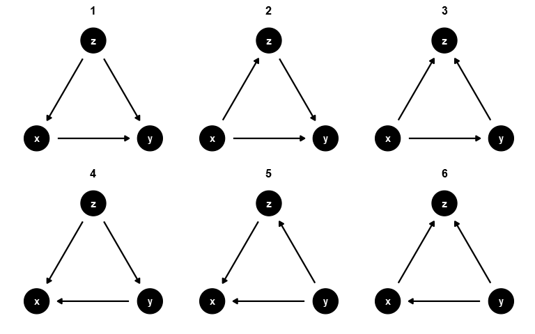

## Causal Diagrams

- With only the data to work with we have *no way of knowing* which of those is true
- Maybe `IP.spend` causes companies to be `tech` companies (in 2, 3, 6)
- We know that’s silly because we have an idea of what the model is
- If you started by noticing that $corr(tech,IP.spend)>0$, you could make this mistake

## Practice

Look at the diagram on the next page, intended to be a model of fertility decisions in Switzerland based on education and whether one comes from an agricultural family.

Ask:

1. What assumptions are in the graph?
2. Assuming the graph is true, why are Education and Fertility related?
3. Do any of the assumptions seem wrong?

## Practice

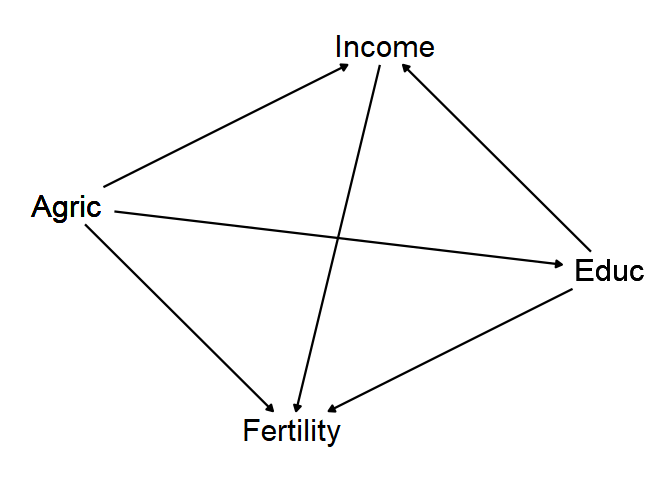